# Competitive Analysis Through Topic Modeling

## Background

The VP of US eCommerce at *Transcend* (a Taiwanese electronics company) has witnessed sales for its SD card on Amazon eroding from 2013 to 2015 (the “present”). The VP says that while star score has increased, sales have been dropping. The VP says that he thinks Transcend has been the sales leader on Amazon since it joined Amazon in 2010.

He has approached your team to diagnose what may be going on in the Amazon ecosystem, and to start with competitive analysis.

```r
# load in data
setwd('/Users/Alex.Shypula@ibm.com/Documents/Other/Tambe')
electronics <- read.csv('Electronics_All.csv')
print(dim(electronics))
```

```
[1] 1689188      10
```

```r
head(electronics, 1)
```

```
  X       asin helpful overall
1 0 0528881469  [0, 0]       5
                                                                                                                                                                                                                                                                                                            …
1 We got this GPS for my husband who is an (OTR) over the road trucker.  Very Impressed with the shipping time, it arrived a few days earlier than expected...  within a week of use however it started freezing up... could of just been a glitch in that unit.  Worked great when it worked!  Will work gr…
  reviewTime    reviewerID reviewerName         summary unixReviewTime
1 06 2, 2013 AO94DHGC771SJ      amazdnu Gotta have GPS!     1370131200
```

## Preliminary filtering

We’re interested only in reviews which are about SD cards, because our client is a sd card manufacturer. We don’t know what are the top selling sd cards, so we can find them by investigating reviews that contain “sd” in the text.

After we isolate potential candidates, then we can use an amazon search to investigate what the product actually is

```r
sd_cards <- electronics[grep("sd", electronics$reviewText), ]
head(sd_cards, 1)
```

```
      X       asin helpful overall
245 244 1400501466  [0, 0]       3
                                                                                                                                                                                                                                                                                                            …
245 When B&N; designed this one, they were putting together a reading device that also happened to have some tablet features. As a result, what you get is pretty limited.It's a fairly sturdy device by feel, and not difficult to hold for a while and use. The quality of the screen is pretty good and i…
     reviewTime     reviewerID reviewerName                           summary unixReviewTime
245 06 20, 2013 A2XIOXRRYX0KZY         B.L. Decent Little Reader, Poor Tablet     1371686400
```

If we google or amazon search for asin **1400501466** we find the Barnes & Noble Nook Tablet.

Asin stands for **amazon standard identificaiton number.** We can find out what products in the “sd” area are leading products by counting which asins appear most frequently. We do this by aggregating and then sorting in descending order

```r
sd_cards_aggregate <- aggregate(sd_cards['asin'], by = sd_cards['asin'], FUN = length)
colnames(sd_cards_aggregate)<- c('asin', 'count')
head(sd_cards_aggregate[order(-sd_cards_aggregate$count), ], n = 10)
```

```
           asin count
4277 B007WTAJTO   273
5372 B00E3W15P0    93
952  B000VX6XL6    89
1915 B002MAPRYU    74
2886 B004G6002M    68
3234 B004W2JKWG    57
2051 B002WE6D44    47
440  B000BQ7GW8    45
4202 B007P4VOWC    45
4764 B009NB8WR0    44
```

After searching the asins online, we see the first and the third are sd cards, and the seventh is our client’s sd card.

The second is a solid state drive (‘sd’ accidentially returned us with ‘ssd’ as well because ‘sd’ is a substring of ‘ssd’).

Next, we can generate some basic summary statistics on the sandisk, kingston, and transcend products to understand what general information exists.

```r
sandisk<-electronics[electronics$asin == 'B007WTAJTO',]
# a second post processing step is done (LDA cannot work with 0 words in a document)
sandisk<-sandisk[sandisk$reviewText!='', ]
kingston <- electronics[electronics$asin =='B000VX6XL6',]
kingston<-kingston[kingston$reviewText!='', ]
transcend <- electronics[electronics$asin =='B002WE6D44',]
transcend<-transcend[transcend$reviewText!='', ]
# code to print summary statistics is hidden
```

```
summary statistics for sandisk
[1] "number of reviews is 4914"
[1] "mean is 4.58750508750509"
[1] "median is 5"
[1] "summary statistics for sandisk"
[1] "standard deviation is 0.996929216793204"


summary statistics for kingston
[1] "number of reviews is 1556"
[1] "mean is 4.60668380462725"
[1] "median is 5"
[1] "standard deviation is 0.901335375317442"


summary statistics for trancend
[1] "number of reviews is 2813"
[1] "mean is 4.65979381443299"
[1] "median is 5"
[1] "standard deviation is 0.875910962582041"
```

## Pivot to Deep Dive

Given that the Sandisk asin has more reviews than the transcend, the VP of Sales says he wants to learn more about the Sandisk product (the leading product) in particular. He wants to know if data science can reveal relative strengths, weakness, and anything else about the two products that can be learned.

### Step 1: Graph the monthly review average for both sandisk and transcend

#### part a: aggregate average review rating by month

#### part b: visualize over time

```r
require(stringr)
require(lubridate)
require(ggplot2)
# Step 1: Graph the average monthly review average for both sandisk and transcend
  # part a: aggregate average review rating by month
# concatenate the sandisk and transcend dataframes
sandisk_and_transcend <- rbind(sandisk, transcend)
# make a column to identify the maker as Sandisk or Transcend (very useful for ggplot2)
sandisk_and_transcend$maker <- ifelse(sandisk_and_transcend$asin == 'B007WTAJTO', 'Sandisk', 'Transcend')
# wrangle date from reviewtime
# a simpler implementation could probably be done using the anytime package
mon_day_year <- as.data.frame(str_split_fixed(as.character(sandisk_and_transcend$reviewTime), " |, ", n = 3))
mon_day_year <- as.data.frame(sapply(mon_day_year, as.factor))
colnames(mon_day_year)<-c('month', 'day', 'year')
# merge back with the original dataframe
sandisk_and_transcend <- cbind(sandisk_and_transcend, mon_day_year)
# aggregate review average by month and year
sandisk_and_transcend_monthly <- aggregate(sandisk_and_transcend$overall, by = list(sandisk_and_transcend$maker, sandisk_and_transcend$month, sandisk_and_transcend$year), FUN = mean)
# assign column names
colnames(sandisk_and_transcend_monthly)<- c('maker', 'month', 'year', 'overall')
# turn date into a date object and set to first day of the month as default
sandisk_and_transcend_monthly$date <- as.Date(paste('01', sandisk_and_transcend_monthly$month, sandisk_and_transcend_monthly$year, sep = '/'), '%d/%m/%Y')
head(sandisk_and_transcend_monthly)
```

```
      maker month year  overall       date
1 Transcend    03 2010 5.000000 2010-03-01
2 Transcend    05 2010 5.000000 2010-05-01
3 Transcend    10 2010 5.000000 2010-10-01
4 Transcend    11 2010 4.800000 2010-11-01
5 Transcend    12 2010 4.250000 2010-12-01
6 Transcend    01 2011 4.153846 2011-01-01
```

Now that we have the data aggregated and converted into a date format, we can now move to part b, visualizing.

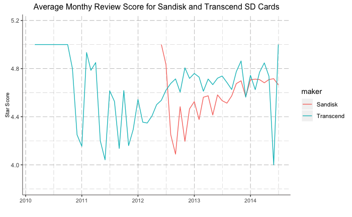

```r
# Step 1: Graph the average monthly review average for both sandisk and transcend
  # part b: visualize over time
ggplot(sandisk_and_transcend_monthly,
       aes(x=date,y=overall,color=maker)) +
theme(panel.background = element_rect(fill = "white"),
      axis.line=element_line(color = "snow4",
                             size=.5,
                             linetype='solid'),
      panel.grid.major.y = element_line(size = 0.2,
                                        linetype='longdash',
                                        color="snow4"),
      panel.grid.major.x = element_line(size= 0.2,
                                        linetype='longdash',
                                        color="snow4"),
      panel.grid.minor.y = element_line(size = .1,
                                        linetype="longdash",
                                        color="snow4"), #makes minor axis invisible, but able to be customized
      panel.grid.minor.x = element_line(size = .1,
                                        linetype="longdash",
                                        color="snow4"), #makes minor axis invisible, but able to be customized
      axis.text.x = element_text(angle = 0, hjust = .5, family="Arial", size = 8),
      axis.title.x = element_blank(), #removed x-axis "Date" title
      axis.title.y = element_text(angle = 90, hjust = 0.5, vjust=0, family = "Arial", size = 8),
      plot.title = element_text(hjust = 0.5, family = "Arial", size = 12),
)+
scale_y_continuous(expand=c(0,0), lim = c(3.75, 5.25))+
geom_line(stat="identity")+
ylab("Star Score")+
ggtitle("Average Monthy Review Score for Sandisk and Transcend SD Cards")+
labs(caption= "")
```

### Step 2: Find which words are highest correlated with positive reviews and negative reviews for both sandisk and transcend, and visualize using wordclouds

#### part a: use the tm package to process the text and create a dtm

#### part b: calculate correlation of words with the overall star score

#### part c: visualize top words using word clouds

#### part d: repeat for other company

```r
# Step 2: Find which words are highest correlated with positive reviews and negative reviews for both sandisk and transcend, and visualize using wordclouds
  # part a: use the tm package to process the text and create a dtm
require(tm)
require(textstem)
# uncomment the print steps to see what happens at each stage of the pipeline
reviews_sandisk <- Corpus(VectorSource(sandisk$reviewText))
#print(writeLines(as.character(reviews_sandisk[5])))
reviews_sandisk<-tm_map(reviews_sandisk, content_transformer(tolower))
#print(writeLines(as.character(reviews_sandisk[5])))
reviews_sandisk<-tm_map(reviews_sandisk, removeWords, stopwords("english"))
#print(writeLines(as.character(reviews_sandisk[5])))
reviews_sandisk<-tm_map(reviews_sandisk, lemmatize_strings)
#print(writeLines(as.character(reviews_sandisk[5])))
reviews_sandisk<-tm_map(reviews_sandisk, stripWhitespace)
print(writeLines(as.character(reviews_sandisk[5])))
```

```
buy retail package, arrive legit, orange envelope, english version asian like picture show. arrive quickly, buy 32 16 retail package htc one sv lg optimus, card work order, probably good price get nice sd card
list(language = "en")
list()
NULL
```

```r
# create dtm
reviews_dtm_sandisk<-DocumentTermMatrix(reviews_sandisk)
```

Now that we have a dtm, we can now find the correlations between the word counts and overall star rating. The easiest (albeit highly inefficient) way seems to be to append the star score column to the dtm, calculate a correlation matrix, and then subset the star score column of the correlation matrix.

```r
# Step 2: Find which words are highest correlated with positive reviews and negative reviews for both sandisk and transcend, and visualize using wordclouds
  # part b: calculate correlation of words with the overall star score
# append the review score
reviews_dtm_matrix_sandisk<-cbind(sandisk$overall, as.matrix(reviews_dtm))
colnames(reviews_dtm_matrix_sandisk)[1] <- 'overall_star_rating'
# calcualte a correlation matrix
correlation_matrix_sandisk<-cor(reviews_dtm_matrix_sandisk)
correlation_table_sandisk<- as.data.frame(as.table(correlation_matrix_sandisk))
# filter out only the correlations between word frequencies and the target variable
correlation_table_sandisk<-correlation_table_sandisk[correlation_table_sandisk$Var1 == 'overall_star_rating' & correlation_table_sandisk$Var2 != 'overall_star_rating', ]
# sort correlations in descending order
correlation_table_sandisk<-correlation_table_sandisk[order(-correlation_table_sandisk$Freq), c('Var2', 'Freq')]
colnames(correlation_table_sandisk)<-c('word', 'correlation')
correlation_table_positives_sandisk <- correlation_table_sandisk[1:20, ]
correlation_table_negatives_sandisk <- correlation_table_sandisk[(nrow(correlation_table_sandisk)-20):(nrow(correlation_table_sandisk)), ]
print(rbind(correlation_table_positives_sandisk,correlation_table_negatives_sandisk ))
```

```
                word correlation
295057         great  0.07398405
532741         price  0.04587322
1131049        space  0.04438141
1098265         fast  0.04344517
1786729         love  0.03354571
688465       storage  0.03324479
4679917       anyone  0.03285064
1499869       highly  0.03036518
2221117         room  0.02982709
5171677      perfect  0.02913970
36849217   powershot  0.02881635
2008021         easy  0.02723482
1303165          fit  0.02584102
4753681        worry  0.02552368
```

[output cut: 27 more lines]

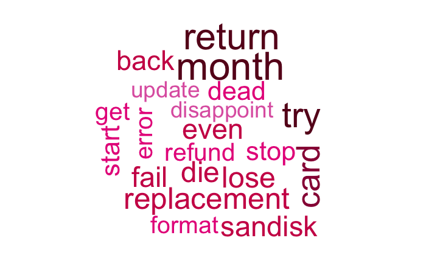

```r
# Step 2: Find which words are highest correlated with positive reviews and negative reviews for both sandisk and transcend, and visualize using wordclouds
  # part c: visualize top words using word clouds
require(wordcloud)
require(RColorBrewer)
pal<-brewer.pal(9, 'PuRd')
wordcloud(correlation_table_negatives_sandisk$word, (correlation_table_negatives_sandisk$correlation*-100), random.color = F, colors = pal)
```

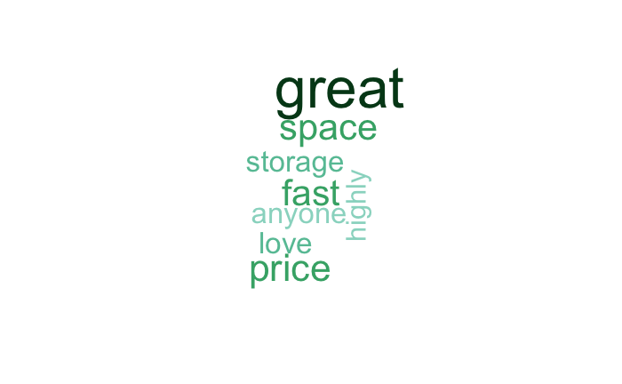

```r
pal<-brewer.pal(9, 'BuGn')
wordcloud(correlation_table_positives_sandisk$word, (correlation_table_positives_sandisk$correlation*100), random.color = F, colors = pal)
```

Now we’ll repeat the same analysis for transcend.

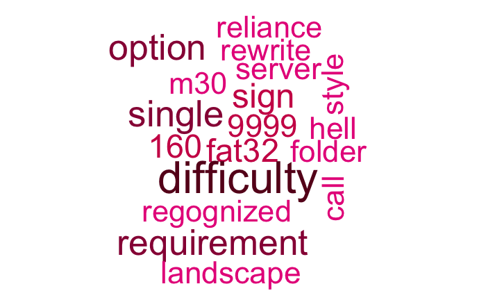

```r
# Step 2: Find which words are highest correlated with positive reviews and negative reviews for both sandisk and transcend, and visualize using wordclouds
  # part d: repeat for other company
# perform the same analysis now for our client transcend
reviews_transcend <- Corpus(VectorSource(transcend$reviewText))
reviews_transcend<-tm_map(reviews_transcend, content_transformer(tolower))
reviews_transcend<-tm_map(reviews_transcend, removeWords, stopwords("english"))
reviews_transcend<-tm_map(reviews_transcend, lemmatize_strings)
reviews_transcend<-tm_map(reviews_transcend, stripWhitespace)
reviews_dtm_transcend<-DocumentTermMatrix(reviews_transcend)
reviews_dtm_matrix_transcend<-cbind(sandisk_and_transcend$overall, as.matrix(reviews_dtm_transcend))
colnames(reviews_dtm_matrix_transcend)[1] <- 'overall_star_rating'
correlation_matrix_transcend<-cor(reviews_dtm_matrix_transcend)
correlation_table_transcend<- as.data.frame(as.table(correlation_matrix_transcend))
correlation_table_transcend<-correlation_table_transcend[correlation_table_transcend$Var1 == 'overall_star_rating' & correlation_table_transcend$Var2 != 'overall_star_rating', ]
correlation_table_transcend<-correlation_table_transcend[order(-correlation_table_transcend$Freq), c('Var2', 'Freq')]
colnames(correlation_table_transcend)<-c('word', 'correlation')
correlation_table_positives_transcend <- correlation_table_transcend[1:20, ]
correlation_table_negatives_transcend <- correlation_table_transcend[(nrow(correlation_table_transcend)-20):(nrow(correlation_table_transcend)), ]
pal<-brewer.pal(9, 'PuRd')
wordcloud(correlation_table_negatives_transcend$word, (correlation_table_negatives_transcend$correlation*-100), random.color = F, colors = pal)
```

[figure not shown]

```r
pal<-brewer.pal(9, 'BuGn')
wordcloud(correlation_table_positives_transcend$word, (correlation_table_positives_transcend$correlation*100), random.color = F, colors = pal)
```

### Step 3: Fit LDA model and see performance by topic

#### part a: Fit LDA Model (first merge dataframes of both, then fit model)

#### part b: Determine each topic’s meaning

#### part c: aggregate the gamma matrix (document topic distributions) by each company

#### part d: Use bar charts to visualize topic frequency differences between the two competitors

First use a dataframe that contains the row-binded results of both sandisk and transcend reviews. Perform the same text processing, and then fit an LDA model.

From tinkering, **Gibbs Sampling** yielded better results.

```r
require(topicmodels)
# Step 3: Fit LDA model and see performance by topic
  # part a: Fit LDA Model

reviews<- Corpus(VectorSource(sandisk_and_transcend$reviewText))
reviews<-tm_map(reviews, content_transformer(tolower))
reviews<-tm_map(reviews, removeWords, stopwords("english"))
reviews<-tm_map(reviews, lemmatize_strings)
reviews<-tm_map(reviews, stripWhitespace)
reviews_dtm<-DocumentTermMatrix(reviews)
lda <- LDA(reviews_dtm, k = 7, method = "Gibbs", control = list(seed = 1234))
```

For class, students should use the simple terms function which seems to return top terms from the beta matrix. I experimented with normalizing by the sum of all probabilities.

```r
# Step 3: Fit LDA model and see performance by topic
  # part b: Determine each topic's meaning
terms(lda, 10)
```

```
      Topic 1    Topic 2   Topic 3   Topic 4   Topic 5    Topic 6    Topic 7
 [1,] "card"     "camera"  "phone"   "card"    "memory"   "card"     "work"
 [2,] "speed"    "use"     "galaxy"  "get"     "buy"      "use"      "great"
 [3,] "class"    "video"   "storage" "one"     "good"     "format"   "good"
 [4,] "fast"     "picture" "samsung" "sandisk" "product"  "device"   "price"
 [5,] "write"    "take"    "tablet"  "time"    "purchase" "come"     "say"
 [6,] "read"     "photo"   "space"   "will"    "one"      "adapter"  "recommend"
 [7,] "transfer" "card"    "music"   "problem" "problem"  "computer" "much"
 [8,] "size"     "can"     "store"   "amazon"  "use"      "file"     "fast"
 [9,] "sandisk"  "record"  "just"    "month"   "never"    "can"      "far"
[10,] "sdhc"     "lot"     "note"    "just"    "brand"    "datum"    "really"
```

```r
 # this is a different method to find top words, probably too complex for our class, ctrl shift c to use
 probs <- exp(lda@beta)
 probs_normalized <- probs / colSums(probs)
 terms <- lda@terms
 topic_df<-data.frame(matrix(ncol = 7, nrow = 20))
 colnames(topic_df) <- c('Topic1',
                    'Topic2',
                    'Topic3',
                    'Topic4',
                    'Topic5',
                    'Topic6',
                    'Topic7')
 for (i in 1:nrow(probs_normalized)){
   term_vector<-probs_normalized[i,]
   top_ten_idx<-order(term_vector, decreasing = T)[1:20]
   top_terms<-terms[top_ten_idx]
   topic_df[, i]<-top_terms
 }
topic_df
```

```
     Topic1    Topic2  Topic3  Topic4     Topic5   Topic6     Topic7
1     write      take    need    time       good   device  recommend
2     speed   picture     new    will        use   format      gopro
3      size     photo install  amazon  transcend    datum       work
4      16gb     video   extra sandisk    quality computer      right
5      file     shoot   store    just       need      put    perfect
6      rate     canon    play    know    product   laptop        buy
7   perform   without samsung     day    several     even        job
8       low      need    able   first        buy      usb    exactly
9      just       use     run  review    problem     copy     highly
10      8gb     worry     gig   still     memory   window       fine
11     like     still   micro another        big     32gb       fast
12      uhs      hour  amount problem definitely    fat32        say
13    class    almost    just     bad  excellent   insert flawlessly
14 actually      many upgrade    fine      flash     free        fit
15     full     quick    love    even      wrong  microsd      great
16    small camcorder    save    last       cost  require       else
17   device      save   music    ship       year    exfat  perfectly
18     numb      sony    wife   start       many     sdxc    awesome
19      use       lag    fast  return       want     will  complaint
20      sec    camera   movie     way       sure   system      thank
```

Determine the topic names from the information given. Topic 5 seems both good and bad, so we’ll keep it “uncertain.” We then should average the topic probabilities by each maker’s reviews to find out if customer reviews tend to fall in one or another category.

```r
# record the topic names
topic_names<-c('Performance1', 'Usage', 'Performance2', 'Problems', 'Uncertain', 'Performance3', 'Positive' )
# Step 3: Fit LDA model and see performance by topic
  # part c: aggregate the gamma matrix (document topic distributions) by each company
# extract the topic distributions for sandisk from the gamma matrix
sandisk_docs<-lda@gamma[which(sandisk_and_transcend$maker=="Sandisk"),]
# calculate the average of the topic distributions for sandisk reviews
sandisk_topic_distribution<-colSums(sandisk_docs)/nrow(sandisk_docs)
sandisk_topic_distribution
```

```
[1] 0.1399890 0.1309869 0.1533933 0.1454872 0.1400117 0.1463369 0.1437950
```

```r
# extract the topic distributions for transcend from the gamma matrix
transcend_docs<-lda@gamma[which(sandisk_and_transcend$maker=="Transcend"),]
# calculate the average of the topic distributions for transcend reviews
transcend_topic_distribution<-colSums(transcend_docs)/nrow(transcend_docs)
transcend_topic_distribution
```

```
[1] 0.1426384 0.1643887 0.1254693 0.1400050 0.1487619 0.1336969 0.1450397
```

Now let’s visualize this data side by side using ggplot2

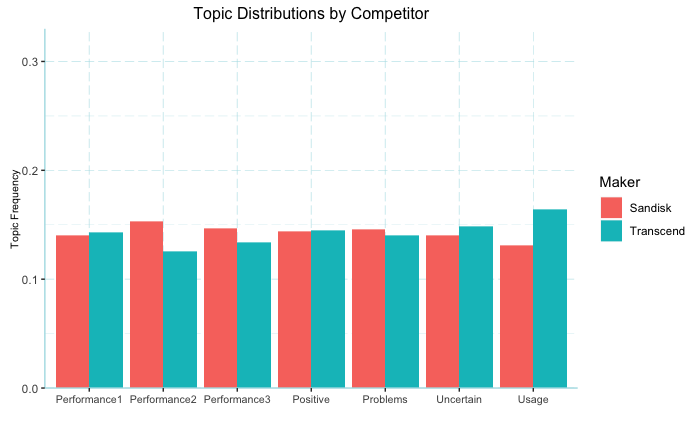

```r
# Step 3: Fit LDA model and see performance by topic
  # part d: Use bar charts to visualize topic frequency differences between the two competitors
# make a dataframe for visualization purposes
Topics <- rep(topic_names, 2)
Maker <- c(rep('Sandisk', 7), rep('Transcend', 7))
Topic_Distributions <- c(sandisk_topic_distribution, transcend_topic_distribution)
company_topic_distributions<-cbind.data.frame(Topics, Maker, Topic_Distributions)
colnames(company_topic_distributions)<-c('Topics', 'Maker', 'Topic_Distributions')
# visualize
company_topic_distributions%>%
  ggplot(aes(x = Topics, y=Topic_Distributions, fill = Maker)) +
  theme(panel.background = element_rect(fill = "white"),
        axis.line=element_line(color = "powderblue",
                               size=.5,
                               linetype='solid'),
        panel.grid.major.y = element_line(size = 0.2,
                                          linetype='longdash',
                                          color="powderblue"),
        panel.grid.major.x = element_line(size= 0.2,
                                          linetype='longdash',
                                          color="powderblue"),
        panel.grid.minor.y = element_line(size = .1,
                                          linetype="longdash",
                                          color="powderblue"), #makes minor axis invisible, but able to be customized
        panel.grid.minor.x = element_line(size = .1,
                                          linetype="longdash",
                                          color="powderblue"), #makes minor axis invisible, but able to be customized
        axis.text.x = element_text(angle = 0, hjust = .5, family="Arial", size = 8),
        axis.title.x = element_blank(), #removed x-axis "Date" title
        axis.title.y = element_text(angle = 90, hjust = 0.5, vjust=0, family = "Arial", size = 8),
        plot.title = element_text(hjust = 0.5, family = "Arial", size = 12),

  )+
  scale_y_continuous(expand=c(0,0), lim = c(0,.33))+
  geom_bar(stat = 'identity', position = "dodge")+
  ylab("Topic Frequency")+
  ggtitle("Topic Distributions by Competitor")+
  labs(caption= "")
```

The last code block here is un-implemented code to make seeded LDA topic modeling, unfortunately not enough time to try to debug the issues with the simple triplet matrix ! Just not enough documentation is out there.

```r
# topic 1 - back, issue, problem, crap, slow, unreliable
# topic 2 - fast, reliable, smoothly, rapidly, consistent, durable
# topic 3 - memory, large, hold, storage, plenty, capacity,
# topic 4 - great, recommend, happy, love, perfect, deal
# topic 5
# topic 6
# topic 7
# was experimenting with setting seed words, but unable to get working in time
#
# seed_words<-c('back', 'issue', 'problem', 'crap', 'error', 'corrput',
#               'fast', 'reliable', 'smoothly', 'rapidly', 'consistent', 'durable',
#               'memory', 'large', 'hold', 'storage', 'plenty', 'capacity',
#               'great', 'recommend', 'happy', 'love', 'perfect', 'deal')
#
#
# which(reviews_dtm[['dimnames']]$Terms == 'back')
#
# seed_words_idx<-unname(sapply(seed_words, function(x) which(reviews_dtm[['dimnames']]$Terms == x )))
# eye <- rep(1:4, each = 6)
# jay <- sapply(seed_words, function(x) which(reviews_dtm[['dimnames']]$Terms == x ))
# length(i)
# length(j)
# ncol(reviews_dtm)
# require(slam)
# ?simple_triplet_matrix
# deltaS <- simple_triplet_matrix(i = eye, j = jay, v = rep(500, 24),nrow = 7, ncol = ncol(reviews_dtm))
#
# ?simple_triplet_matrix
#
# ldaS <- LDA(AssociatedPress, k = 6, method = "Gibbs", seedwords = deltaS,
#             control = list(alpha = 0.1, best = TRUE,
#                            verbose = 500, burnin = 500, iter = 100, thin = 100, prefix = character()))
#
```